# 計分：每個孩子的 WLE

## 0 這份教學

### 你會學到什麼

校準（01_calibration）給了每一題的步驟參數 $\beta$。 這份教學用這些 $\beta$，給每個孩子一個能力分數 $\hat\theta$ 和它的 SE。 kits 的分數叫 WLE（weighted likelihood estimate）。

1. 一個孩子的概似：原始分就夠了（第 2 節）。
2. 測驗訊息 $I(\theta)$（第 3 節）。
3. WLE：概似加上 $\tfrac12\log I$ 的最大值（第 4 節）。
4. Warm 原來的算法：解一個分數方程，得到同一個 $\theta$（第 5 節，只是比較）。
5. SE（第 6 節）。
6. 原始分換算表（第 7 節）。
7. 個人適配：infit 和 outfit（第 8 節）。
8. 貼到新的 R 就能重做的管線（第 10 節）。

每一節都照同樣的順序：

- 這一步做什麼（白話）。
- 公式：排好的數學式，和一模一樣的 LaTeX（右上角的按鈕一鍵複製）。
- 手算：在模擬資料上，用 base R 照公式自己算一次。
- 用 kits 算：`kits_` 一層和 `algo_` 一層各算一次，和手算比。
- 教學程式：`wle.R` 是哪一段；便宜的就直接跑。

### 你需要什麼

- 讀過 01_calibration 的第 3 節（PCM）。
- R 和 kits；整理資料用 dplyr、tidyr、purrr、tibble，畫圖用 ggplot2。

WLE 在 RTMB 裡怎麼寫，在 kits 的模型 的第 4 節。 這份教學需要時指過去，不重複。

```r
library(kits)
library(dplyr)
library(tidyr)
library(purrr)
library(tibble)
library(ggplot2)
```

### 這個算法的總覽

```r
kits_algorithm("wle")
```

```
#> <kits_algorithm> wle: person scores: the weighted likelihood estimate (WLE), its SE and person fit
#> Steps:
#>   1. Log-likelihood of person p from the PCM, over the items answered
#>        log L_p(θ) = r_p θ − Σ_i log S_i(θ),  S_i(θ) = Σ_k exp(kθ − Σ_{g≤k} β_ig)
#>   2. Test information of the items answered
#>        I_p(θ) = Σ_i Var(X_i | θ) = Σ_i Σ_k (k − E_i)² P_ik
#>   3. Jeffreys modal estimate, for the PCM exactly Warm's WLE; one RTMB Newton solve for all
#>        θ̂_p = argmax_θ [ log L_p(θ) + ½ log I_p(θ) ]   (item pattern x raw score)
#>   4. Asymptotic SE of the WLE (Warm, 1989), also for a zero or a perfect score
#>        SE(θ̂_p) = 1 / √I_p(θ̂_p)
#>   5. Person fit at the WLE (W = variance of x_pi)
#>        infit = Σ_i (x − E)² / Σ_i W,  outfit = (1/n) Σ_i (x − E)² / W;  misfit if max > 2
#>   6. Conversion by kits_convert(), each link in turn
#>        θ* = B + A θ,  SE* = A SE,  se_total = √(SE*² + se_link²)
#> Components:
#>   kits_subj(X, item) |> kits_convert(link)
#>   cml <- kits_stats(X) |> algo_cml()
#>   algo_jme(cml$betas)                                        # theta and se per raw score
#>   inside: wle_table(), wle_solve(), add_person_fit(), line_apply()
#> References:
#>   Warm, T. A. (1989). Psychometrika, 54, 427-450.
#>   Firth, D. (1993). Bias reduction of maximum likelihood estimates. Biometrika, 80, 27-38.
#>   Magis, D. (2015). Psychometrika, 80, 200-204 (Jeffreys modal estimation = WLE for the PCM).
#> Read more:
#>   tutorial_algorithms/02_scoring.html
#>   system.file("scripts", "wle.R", package = "kits"), parts: wle, person_fit, convert, warm
```

第 1–4 步是這份教學的第 2–6 節，第 5 步是第 8 節。 第 6 步（換算到別的量尺）在 03_linking。 `Components` 的第二行是簡寫：`algo_jme()` 吃的是 `cml$betas`、每個人次的原始分和答過的題（第 4 節）。

### 三個小工具

和 01_calibration 相同：`script_part()` 讀出教學程式的一段，`run_parts()` 在新的環境裡跑幾段，`same_cols()` 一欄一欄 `identical()`。

```r
script_part <- function(file, part) {
  code <- readLines(system.file("scripts", file, package = "kits"))
  marks <- grep("^# ==== ", code)
  start <- grep(sprintf("^# ==== (part: )?%s ====", part), code)
  end <- c(marks[marks > start], length(code) + 1)[1] - 1
  code[start:end]
}
```

```r
run_parts <- function(file, parts, ...) {
  code <- readLines(system.file("scripts", file, package = "kits"))
  top <- code[seq_len(grep("^# ==== inputs ====", code) - 1)]
  env <- list2env(list(...), envir = new.env(parent = globalenv()))
  body <- unlist(map(parts, \(p) script_part(file, p)))
  printed <- capture.output(suppressMessages(eval(parse(text = c(top, body)), envir = env)))
  env
}
```

```r
same_cols <- function(a, b, cols = names(a)) {
  map_lgl(set_names(cols), \(v) identical(a[[v]], b[[v]]))
}
```

## 1 資料和校準

和 01_calibration 同一份模擬資料：8 題，三個波次，四個作答組合。

```r
set.seed(7)
b <- seq(-2.5, 2, length.out = 8)
betas <- lapply(b, \(x) x + c(-0.5, 0.5))
betas[c(1, 4)] <- b[c(1, 4)]
names(betas) <- sprintf("lan%02d", 1:8)
```

```r
wave_m <- rep(c(6, 12, 24), each = 200)
age_m <- wave_m + runif(600, -1, 1)
theta <- 1.8 * log(age_m / 12) + rnorm(600, 0, 0.9)
X <- kits_sim(theta, betas)
```

```r
X[wave_m == 6, c("lan07", "lan08")] <- NA
X[wave_m == 24, c("lan01", "lan02")] <- NA
X[which(wave_m == 12)[1:10], "lan08"] <- NA
```

校準，再計分。 `persons` 給每個人次的波次和月齡（換算表要用）：

```r
item <- kits_item(X, scale = "lan sim")
cml <- algo_cml(item$stats)
persons <- tibble(visit_id = rownames(X), wave_m, age_m)
s <- kits_subj(X, item, persons = persons)
```

分數表一列一個人次（這裡不印編號）：

```r
as_tibble(s) |>
  select(-visit_id) |>
  head(4)
```

```
#> # A tibble: 4 × 10
#>   pattern_id   raw raw_max  theta    se  infit outfit flag  wave_m age_m
#>   <chr>      <int>   <int>  <dbl> <dbl>  <dbl>  <dbl> <chr>  <dbl> <dbl>
#> 1 bk1            6      10 -0.255 0.713  0.632  0.677 ok         6  6.98
#> 2 bk1            2      10 -2.23  0.808  1.33   0.820 ok         6  5.80
#> 3 bk1            4      10 -1.20  0.712  0.424  0.409 ok         6  5.23
#> 4 bk1            0      10 -4.17  1.57  NA     NA     zero       6  5.14
```

- `raw`：原始分；`raw_max`：答過的題目的滿分加起來。
- `theta`、`se`：WLE 和它的 SE。
- `infit`、`outfit`、`flag`：個人適配（第 8 節）。

`cml$betas` 是一題一個向量的步驟參數，`algo_` 一層的計分都吃它：

```r
str(cml$betas[1:2])
```

```
#> List of 2
#>  $ lan01: num -2.32
#>  $ lan02: num [1:2] -2.33 -1.37
```

## 2 一個孩子的概似

### 做什麼

概似 $L_p(\theta)$ 是「這個孩子剛好這樣作答」的機率，當成 $\theta$ 的函數。 它是答過的每一題的 PCM 機率相乘。 在 PCM 裡，它只透過原始分 $r_p$ 和 $\theta$ 有關。 所以同一組題目、同樣的原始分，分數一定相同。

### 公式

$$\log L_p(\theta) = r_p\,\theta - \sum_i \log S_i(\theta) + c, \qquad
S_i(\theta) = \sum_{k=0}^{m_i} \exp\Big(k\theta - \sum_{g=1}^{k}\beta_{ig}\Big)$$

```latex
\log L_p(\theta) = r_p\,\theta - \sum_i \log S_i(\theta) + c, \qquad
S_i(\theta) = \sum_{k=0}^{m_i} \exp\Big(k\theta - \sum_{g=1}^{k}\beta_{ig}\Big)
```

- $i$：孩子 $p$ 答過的題目。
- $S_i$：題目 $i$ 的 PCM 分母。
- $c = -\sum_i \sum_{g \le x_{pi}} \beta_{ig}$：和 $\theta$ 無關的常數。

### 手算

PCM 的類別機率（01_calibration 第 3 節）：

```r
pcm <- function(theta, beta) {
  eta <- c(0, cumsum(theta - beta))
  exp(eta) / sum(exp(eta))
}
```

第一個 `ok` 的孩子，和他答過的題目：

```r
p1 <- which(s$flag == "ok")[1]
x <- X[p1, !is.na(X[p1, ])]
x
```

```
#> lan01 lan02 lan03 lan04 lan05 lan06
#>     1     1     2     1     1     0
```

$\log L$ 照定義（機率相乘），和照公式（只用原始分）：

```r
log_lik <- function(t) sum(log(map2_dbl(names(x), x, \(i, k) pcm(t, cml$betas[[i]])[k + 1])))
c_p <- -sum(map2_dbl(names(x), x, \(i, k) sum(cml$betas[[i]][seq_len(k)])))
log_S <- function(t) map_dbl(cml$betas[names(x)], \(b) algo_pcm(t, b)$log_S)
log_lik_r <- function(t) sum(x) * t - sum(log_S(t)) + c_p
```

兩個寫法在每個 $\theta$ 都相同：

```r
th <- c(-2, 0, 1.5)
all.equal(map_dbl(th, log_lik), map_dbl(th, log_lik_r), tolerance = 1e-12)
```

```
#> [1] TRUE
```

`algo_pcm()` 的 `log_S` 就是 $\log S_i(\theta)$。

### 原始分就夠了

分數表裡，不重複的「作答組合 × 原始分」比人次少很多：

```r
as_tibble(s) |>
  summarise(n_theta = n_distinct(theta), .by = c(pattern_id, raw)) |>
  summarise(combos = n(), max_theta_per_combo = max(n_theta))
```

```
#> # A tibble: 1 × 2
#>   combos max_theta_per_combo
#>    <int>               <int>
#> 1     40                   1
```

一個組合只有一個 $\theta$。 所以 kits 一個組合只估一次，再接回每個人次。

## 3 測驗訊息

### 做什麼

訊息 $I(\theta)$ 說這組題目在 $\theta$ 附近量得多準。 PCM 的訊息就是每題分數的變異數加起來。 它的倒數開根號，大約是 $\hat\theta$ 的 SE。

### 公式

$$I_p(\theta) = \sum_i \mathrm{Var}(X_i \mid \theta) = \sum_i \sum_k (k - E_i)^2 P_{ik},
\qquad E_i = \sum_k k\,P_{ik}$$

```latex
I_p(\theta) = \sum_i \mathrm{Var}(X_i \mid \theta) = \sum_i \sum_k (k - E_i)^2 P_{ik},
\qquad E_i = \sum_k k\,P_{ik}
```

### 手算

一題的變異數，再加起來：

```r
item_var <- function(t, b) {
  P <- pcm(t, b)
  k <- seq_along(P) - 1
  sum((k - sum(k * P))^2 * P)
}
info_hand <- function(t) sum(map_dbl(cml$betas[names(x)], \(b) item_var(t, b)))
```

### 用 kits 算

`kits_information()` 給一組題目的 $I(\theta)$；`algo_pcm()` 的 `Var` 是每題的變異數：

```r
info_kits <- kits_information(item, items = names(x))
info_algo <- function(t) sum(map_dbl(cml$betas[names(x)], \(b) algo_pcm(t, b)$Var))
c(kits = all.equal(map_dbl(th, info_hand), info_kits(th), tolerance = 1e-12),
  algo = all.equal(map_dbl(th, info_hand), map_dbl(th, info_algo), tolerance = 1e-12))
```

```
#> kits algo
#> TRUE TRUE
```

`kits_pcm_prob(item, theta)` 也印得出每題的變異數和訊息的斜率 $I'(\theta)$（01_calibration 第 3 節）。

## 4 WLE：Jeffreys 眾數

### 做什麼

直接最大化 $\log L$ 是最大概似估計（MLE）。 題目少時，MLE 往兩端偏；0 分和滿分的孩子，MLE 是 $\pm\infty$。 Warm（1989）加上 $\tfrac12\log I(\theta)$，偏誤變小，而且每個孩子都有有限的分數。 這就是 WLE。

$\tfrac12\log I$ 剛好是 Jeffreys 先驗 $\sqrt{I(\theta)}$ 取對數。 所以這個最大值也是 Jeffreys 先驗的後驗眾數（Firth, 1993）。 對 PCM，Warm 的 WLE 和 Jeffreys 眾數完全相同（Magis, 2015）。 kits 就直接最大化 $\log L + \tfrac12\log I$，用 RTMB 的牛頓法（`algo_jme()`）。

### 公式

$$\hat\theta_p = \arg\max_\theta \Big[\log L_p(\theta) + \tfrac12 \log I_p(\theta)\Big]$$

```latex
\hat\theta_p = \arg\max_\theta \Big[\log L_p(\theta) + \tfrac12 \log I_p(\theta)\Big]
```

### 手算

第 2 節的孩子：要最大化的 $f$，用 `optimize()` 找最大值（不需要導數）：

```r
f <- function(t) log_lik(t) + 0.5 * log(info_hand(t))
theta_hand <- optimize(f, c(-10, 10), maximum = TRUE, tol = 1e-10)$maximum
c(by_hand = theta_hand, kits = s$theta[p1])
```

```
#>    by_hand       kits
#> -0.2545823 -0.2545823
```

`optimize()` 只到大約 $10^{-8}$，所以在 $10^{-6}$ 以內比：

```r
all.equal(theta_hand, s$theta[p1], tolerance = 1e-6)
```

```
#> [1] TRUE
```

$f$ 是兩條曲線加起來：$\log L$（灰）和 $\tfrac12\log I$（橘）。 WLE（藍的最高點）比 MLE（灰的最高點）靠近中間一點。

```r
curves <- tibble(theta = seq(-4, 3, by = 0.05)) |>
  mutate(`log L` = map_dbl(theta, log_lik),
         `1/2 log I` = 0.5 * log(map_dbl(theta, info_hand)),
         f = `log L` + `1/2 log I`) |>
  pivot_longer(-theta, names_to = "curve")
```

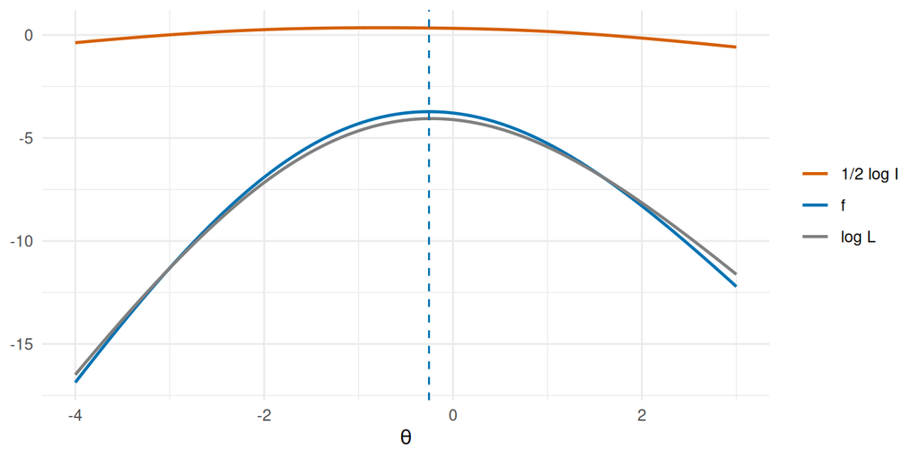

```r
colours <- c(`log L` = "#7F7F7F", `1/2 log I` = "#D55E00", f = "#0072B2")
ggplot(curves, aes(theta, value, colour = curve)) +
  geom_line(linewidth = 0.8) +
  geom_vline(xintercept = s$theta[p1], colour = "#0072B2", linetype = "dashed") +
  scale_colour_manual(values = colours) +
  labs(x = expression(theta), y = NULL, colour = NULL) +
  theme_minimal()
```

### 用 kits 算

`kits_subj()` 的 `theta` 和 `se`，和 `algo_jme()` 一個人次一列算的完全相同：

```r
raw <- rowSums(X, na.rm = TRUE)
sets <- apply(!is.na(X), 1, \(z) colnames(X)[z], simplify = FALSE)
jme <- algo_jme(cml$betas, raw = raw, items = sets)
c(theta = identical(jme$theta, s$theta), se = identical(jme$se, s$se))
```

```
#> theta    se
#>  TRUE  TRUE
```

- 起始值和 TAM 相同：這組題的 $\beta$ 的平均，加上 $\log\frac{r + 0.5}{\text{滿分} - r + 1}$。
- 所有組合的 $-f$ 加起來錄成一個 RTMB tape，`$newton()` 一次解出全部。
- $f$ 有兩個高點時（題目很少、難度差很遠），kits 取 $f$ 比較高的那一個（目標函數值決定）；一樣高時取 $\theta$ 小的那個。

0 分和滿分的孩子也有有限的 WLE：

```r
as_tibble(s) |>
  filter(flag %in% c("zero", "perfect")) |>
  distinct(pattern_id, raw, theta, se, flag)
```

```
#> # A tibble: 2 × 5
#>   pattern_id   raw theta    se flag
#>   <chr>      <int> <dbl> <dbl> <chr>
#> 1 bk1            0 -4.17  1.57 zero
#> 2 bk4           11  4.13  1.54 perfect
```

### 寫在方法裡的一句話

> We estimated person ability with the weighted likelihood estimator (WLE; Warm, 1989). For the partial credit model, the WLE equals the mode of the likelihood penalized by the Jeffreys prior (Firth, 1993; Magis, 2015). We therefore computed it by maximizing ℓ(θ) + ½ log I(θ) in RTMB.

### 教學程式

`wle.R` 的 `wle` 段：`item_terms()` 給 $\log S_i$ 和 $\mathrm{Var}_i$，`neg_f()` 是 $-f$，`MakeTape(neg_f, ...)$newton()` 解出 $\theta$。

```r
# ==== part: wle ====
# 1 The raw score is sufficient: log L(theta) = r theta - sum_i log S_i(theta), with
#   S_i = sum_k exp(k theta - sum_{g <= k} beta_ig). So there is one theta per item pattern x raw
#   score (a combination), each from its first person
beta_of <- cf |>
  arrange(item_score) |>
  summarise(beta = list(beta), .by = item_id) |>
  pull(beta, name = item_id)
long <- as_tibble(X, rownames = "visit_id") |>
  pivot_longer(-visit_id, names_to = "item_id", values_to = "x", values_drop_na = TRUE)
persons <- long |>
  summarise(set = paste(sort(item_id), collapse = " "), r = sum(x), .by = visit_id)
combos <- distinct(persons, set, r)
sets <- strsplit(combos$set, " ", fixed = TRUE)
r <- combos$r

# 2 f(theta) = log L(theta) + 1/2 log I(theta), the PCM information I = sum_i Var(X_i | theta);
#   every combination in one function of the vector theta, written with RTMB values
rows_of <- map(set_names(names(beta_of)), \(i) which(map_lgl(sets, \(set) i %in% set)))
item_terms <- function(theta, beta_i) {                         # log S_i(theta), Var(X_i | theta)
  k <- seq(0, length(beta_i))
  eta <- outer(theta, k) - rep(c(0, cumsum(beta_i)), each = length(theta))
  S <- drop(exp(eta) %*% rep(1, length(k)))
  P <- exp(eta) / S                                             # P(X_i = k | theta)
  E <- drop(P %*% k)
  list(log_S = log(S), var = drop((P * outer(-E, k, "+")^2) %*% rep(1, length(k))))
}
f_parts <- function(theta) {                                    # sum_i log S_i and I
  "[<-" <- ADoverload("[<-")
  log_S <- numeric(length(theta))
  info <- numeric(length(theta))
  for (i in names(rows_of)) {
    rows <- rows_of[[i]]
    terms <- item_terms(theta[rows], beta_of[[i]])
    log_S[rows] <- log_S[rows] + terms$log_S
    info[rows] <- info[rows] + terms$var
  }
  list(log_S = log_S, info = info)
}

# 3 Maximize f with RTMB's Newton method (tape$newton(); the Hessian is diagonal), from the start
#   value of TAM; with two maxima (few items far apart) it keeps the one it reaches (kits: the
#   higher one)
mean_beta <- map_dbl(sets, \(set) mean(unlist(beta_of[set])))
max_raw <- map_dbl(sets, \(set) sum(lengths(beta_of[set])))
theta0 <- mean_beta + log((r + 0.5) / (max_raw - r + 1))
neg_f <- function(d) {
  theta <- theta0 + d
  parts <- f_parts(theta)
  -sum(r * theta - parts$log_S + 0.5 * log(parts$info))
}
solve_f <- MakeTape(neg_f, numeric(length(r)))$newton(seq_along(r), grad_tol = 1e-12)
theta <- theta0 + solve_f(numeric(0))

# 4 SE = 1 / sqrt(I(theta)), the asymptotic SE of the WLE (Warm, 1989); then each person
combos <- mutate(combos, theta = theta, se = 1 / sqrt(f_parts(theta)$info))
subj <- persons |>
  left_join(combos, by = c("set", "r")) |>
  transmute(visit_id, raw = r, theta, se)
head(subj)
```

這一段很便宜，直接在我們的 `X` 上跑（換掉 `inputs`：放進 `X` 和題目參數 `cf`）。 `person_fit`（第 8 節）和 `warm`（第 5 節）兩段一起跑：

```r
cf <- select(coef(item), item_id, item_score, beta)
env <- run_parts("wle.R", c("wle", "person_fit", "warm"), X = X, cf = cf)
by_id <- match(s$visit_id, env$subj$visit_id)
c(theta = all.equal(env$subj$theta[by_id], s$theta, tolerance = 1e-6),
  se = all.equal(env$subj$se[by_id], s$se, tolerance = 1e-6))
```

```
#> theta    se
#>  TRUE  TRUE
```

程式和 kits 在最佳化的容許誤差（$10^{-6}$）以內相同。

## 5 Warm 原來的算法（只是比較）

### 做什麼

Warm（1989）不是直接最大化 $f$。 他把 MLE 的分數方程（$d\log L/d\theta = 0$）加上一個修正項，再解這個方程。 這一節說明：對 PCM，這個根就是第 4 節的最大值。 它只是比較，不是任何函數的選項。

### 公式

$$\frac{d\log L(\theta)}{d\theta} + \frac{J(\theta)}{2I(\theta)} = 0, \qquad
I = \sum_{i,k} \frac{P_{ik}'^2}{P_{ik}}, \qquad
J = \sum_{i,k} \frac{P_{ik}'\,P_{ik}''}{P_{ik}}$$

```latex
\frac{d\log L(\theta)}{d\theta} + \frac{J(\theta)}{2I(\theta)} = 0, \qquad
I = \sum_{i,k} \frac{P_{ik}'^2}{P_{ik}}, \qquad
J = \sum_{i,k} \frac{P_{ik}'\,P_{ik}''}{P_{ik}}
```

在 PCM 裡，$P_{ik}' = P_{ik}(k - E_i)$，所以：

- $d\log L/d\theta = r - \sum_i E_i$。
- $I = \sum_i \mathrm{Var}_i$，就是第 3 節的訊息。
- $J = \sum_i \sum_k (k - E_i)^3 P_{ik}$，三階中央動差的和，剛好等於 $I'(\theta)$。

所以 Warm 的方程就是 $\frac{d}{d\theta}\big[\log L + \tfrac12\log I\big] = 0$：同一個 $\theta$。

### 手算

`algo_pcm(third = TRUE)` 給每題的 $E$、$\mathrm{Var}$ 和三階中央動差 `M3`：

```r
warm_eq <- function(t) {
  m <- map(cml$betas[names(x)], \(b) algo_pcm(t, b, third = TRUE))
  sum(x) - sum(map_dbl(m, "E")) + sum(map_dbl(m, "M3")) / (2 * sum(map_dbl(m, "Var")))
}
theta_warm <- uniroot(warm_eq, c(-10, 10), tol = 1e-12)$root
all.equal(theta_warm, s$theta[p1], tolerance = 1e-8)
```

```
#> [1] TRUE
```

### 教學程式

`wle.R` 的 `warm` 段：$P'$、$P''$ 和 $d\log S_i/d\theta$ 由 RTMB 的 tape 給（`jacfun()`），`uniroot()` 解方程。

```r
# ==== part: warm ====
# 9 Warm's (1989) own route, for comparison only: the root of the score equation
#   d log L / d theta + J / (2 I) = 0, I = sum_ik P'_ik^2 / P_ik, J = sum_ik P'_ik P''_ik / P_ik,
#   with uniroot(). P', P'' and d log S_i / d theta come from RTMB tapes (jacfun()); then
#   d log L / d theta = r - sum_i d log S_i / d theta. For the PCM J = dI / dtheta, so the root
#   is the maximum of f in step 3 (the Jeffreys modal estimate): the same theta
item_tapes <- map(beta_of, \(beta_i) {
  k <- seq(0, length(beta_i))
  eta <- function(t) t * k - c(0, cumsum(beta_i))
  P <- MakeTape(\(t) exp(eta(t)) / sum(exp(eta(t))), 0)            # P(X_i = k | theta)
  P1 <- P$jacfun()
  log_S <- MakeTape(\(t) log(sum(exp(eta(t)))), 0)
  list(P = P, P1 = P1, P2 = P1$jacfun(), dlog_S = log_S$jacfun())
})
warm_score <- function(theta, set, r) {
  score <- r
  I <- 0
  J <- 0
  for (tp in item_tapes[set]) {
    p <- drop(tp$P(theta))
    p1 <- drop(tp$P1(theta))
    score <- score - drop(tp$dlog_S(theta))
    I <- I + sum(p1^2 / p)
    J <- J + sum(p1 * drop(tp$P2(theta)) / p)
  }
  score + J / (2 * I)
}
warm <- map2_dbl(sets, r, \(set, r_j) {
  uniroot(warm_score, c(-15, 15), set = set, r = r_j, tol = 1e-12)$root
})
max(abs(warm - combos$theta))                                     # the theta of step 3

# With kits: the same root as kits::algo_jme(), the WLE of kits_subj() (about 1e-8)
jme <- kits::algo_jme(beta_of, raw = r, items = sets)
max(abs(warm - jme$theta))
```

第 4 節已經在我們的 `X` 上跑過。 每個組合，Warm 的根和 `algo_jme()` 在 $10^{-8}$ 以內相同：

```r
c(vs_script_wle = max(abs(env$warm - env$combos$theta)) < 1e-8,
  vs_algo_jme = max(abs(env$warm - env$jme$theta)) < 1e-8)
```

```
#> vs_script_wle   vs_algo_jme
#>          TRUE          TRUE
```

## 6 SE

### 做什麼

$\hat\theta$ 的 SE 用測驗訊息：訊息越大，量得越準。 WLE 和 MLE 的漸近變異數相同（Warm, 1989），都是 $1/I(\hat\theta)$。 $I$ 就是第 3 節的訊息，解 $\hat\theta$ 時同一段程式已經算好，不必另外微分。

### 公式

$$\mathrm{SE}(\hat\theta) = \frac{1}{\sqrt{I(\hat\theta)}}$$

```latex
\mathrm{SE}(\hat\theta) = \frac{1}{\sqrt{I(\hat\theta)}}
```

### 手算

```r
se_hand <- 1 / sqrt(info_hand(s$theta[p1]))
all.equal(se_hand, s$se[p1], tolerance = 1e-12)
```

```
#> [1] TRUE
```

0 分和滿分的孩子也有 SE；這些孩子的訊息小，SE 比較大。 kits 0.24.1 以前用 Warm 的式子 $\sqrt{I + (I'/2I)^2}\,/\,I$，比 $1/\sqrt{I}$ 稍大，0 分和滿分差最多。

## 7 原始分換算表

### 做什麼

原始分是充分統計量，所以一個作答組合、一個原始分，就有一個 $\theta$。 換算表讓人不用電腦也能從原始分查到 $\theta$。 每個波次用它的標準題本：最多孩子答的作答組合。

### 公式

$$F_w = \arg\max_F n_w(F), \qquad
\hat\theta(r) = \arg\max_\theta \Big[r\theta - \sum_{i\in F_w}\log S_i(\theta)
+ \tfrac12\log I_{F_w}(\theta)\Big]$$

$$\mathit{pct}_r = 100\, n_r \Big/ \sum_r n_r, \qquad
\mathit{form\_pct} = 100 \sum_r n_r \big/ n_w$$

```latex
F_w = \arg\max_F n_w(F), \qquad
\hat\theta(r) = \arg\max_\theta \Big[r\theta - \sum_{i\in F_w}\log S_i(\theta)
  + \tfrac12\log I_{F_w}(\theta)\Big]

\mathit{pct}_r = 100\, n_r \Big/ \sum_r n_r, \qquad
\mathit{form\_pct} = 100 \sum_r n_r \big/ n_w
```

- $F_w$：波次 $w$ 的標準題本；$n_w(F)$ 是答作答組合 $F$ 的孩子數。
- $n_r$：這個波次在標準題本上得 $r$ 分的孩子數；$n_w$ 是這個波次所有的孩子。

### 用 kits 算

分數表帶著波次，所以直接做換算表：

```r
tab <- kits_subj_table(s)
filter(tab, wave_m == 6)
```

```
#> <kits_subj_table> the standard form of each wave of the data, with counts; scale: lan sim
#>    wave_m n_items raw theta   se  n   pct cum_pct wave_n form_pct
#> 1       6       6   0 -4.17 1.57  5  2.50    2.50    200      100
#> 2       6       6   1 -2.92 0.97 15  7.50   10.00    200      100
#> 3       6       6   2 -2.23 0.81 35 17.50   27.50    200      100
#> 4       6       6   3 -1.69 0.74 31 15.50   43.00    200      100
#> 5       6       6   4 -1.20 0.71 39 19.50   62.50    200      100
#> 6       6       6   5 -0.73 0.70 22 11.00   73.50    200      100
#> 7       6       6   6 -0.25 0.71 22 11.00   84.50    200      100
#> 8       6       6   7  0.24 0.74 18  9.00   93.50    200      100
#> 9       6       6   8  0.78 0.81  8  4.00   97.50    200      100
#> 10      6       6   9  1.45 0.96  5  2.50  100.00    200      100
#> 11      6       6  10  2.63 1.53  0  0.00  100.00    200      100
#> Note: each table converts complete responses to the standard form only.
#>   Wave 12: 10 of 200 person-waves with missing responses are not in the table; score them with kits_subj().
```

12 個月有 10 個孩子漏答第 8 題，不在表裡；每個波次的所有作答組合在 `attr(, "forms")`：

```r
attr(tab, "forms") |>
  select(wave_m, form, type, n)
```

```
#>   wave_m form              type   n
#> 1      6    1          standard 200
#> 2     12    1          standard 190
#> 3     12    2 missing responses  10
#> 4     24    1          standard 200
```

### 手算

6 個月的標準題本是 lan01–lan06。 它的 $\theta$ 就是這 6 題、原始分 0 到 10 的 WLE：

```r
form6 <- sprintf("lan%02d", 1:6)
jme6 <- algo_jme(cml$betas[form6])
t6 <- as_tibble(tab) |>
  filter(wave_m == 6)
c(theta = identical(jme6$theta, t6$theta), se = identical(jme6$se, t6$se))
```

```
#> theta    se
#>  TRUE  TRUE
```

人數和百分比：

```r
n_r <- tabulate(raw[wave_m == 6] + 1, nbins = 11)
c(n = identical(n_r, t6$n), pct = isTRUE(all.equal(100 * n_r / sum(n_r), t6$pct)))
```

```
#>    n  pct
#> TRUE TRUE
```

### 不用資料的表

`kits_subj_table(item)` 給校準的每個作答組合、每個原始分（0 到滿分）的 WLE。 它給現場查分數用：

```r
lookup <- kits_subj_table(item)
count(as_tibble(lookup), pattern_id)
```

```
#> # A tibble: 4 × 2
#>   pattern_id     n
#>   <chr>      <int>
#> 1 bk1           11
#> 2 bk2           13
#> 3 bk3           15
#> 4 bk4           12
```

這個表一次解所有的作答組合，牛頓法停下來的地方差在 $10^{-12}$ 以內：

```r
bk1 <- filter(as_tibble(lookup), pattern_id == "bk1")
all.equal(bk1$theta, jme6$theta, tolerance = 1e-12)
```

```
#> [1] TRUE
```

### 教學程式

換算表沒有自己的程式：它的 $\theta$ 就是 `wle.R` 的 `wle` 段（第 4 節）。

## 8 個人適配

### 做什麼

一個孩子的作答，和模型在他的 $\hat\theta$ 說的一致嗎？ 殘差 $x - E$ 是實際分數減期望分數。 infit 是殘差平方和除以變異數和（用訊息量加權）；outfit 是每個標準化殘差平方的平均（不加權）。 模型成立時兩者約是 1。 這是在 $\hat\theta$ 的殘差（Wright & Masters, 1982）。

### 公式

$$E_{pi} = \sum_k k\,P_{ik}(\hat\theta_p), \qquad
W_{pi} = \sum_k k^2 P_{ik}(\hat\theta_p) - E_{pi}^2$$

$$\text{infit}_p = \frac{\sum_i (x_{pi} - E_{pi})^2}{\sum_i W_{pi}}, \qquad
\text{outfit}_p = \frac{1}{n_p}\sum_i \frac{(x_{pi} - E_{pi})^2}{W_{pi}}, \qquad
\text{misfit} \iff \max(\text{infit}, \text{outfit}) > 2$$

```latex
E_{pi} = \sum_k k\,P_{ik}(\hat\theta_p), \qquad
W_{pi} = \sum_k k^2 P_{ik}(\hat\theta_p) - E_{pi}^2

\text{infit}_p = \frac{\sum_i (x_{pi} - E_{pi})^2}{\sum_i W_{pi}}, \qquad
\text{outfit}_p = \frac{1}{n_p}\sum_i \frac{(x_{pi} - E_{pi})^2}{W_{pi}}, \qquad
\text{misfit} \iff \max(\text{infit}, \text{outfit}) > 2
```

- $n_p$：孩子 $p$ 答過的題數。
- 0 分和滿分的孩子，殘差沒有資訊，所以不算（`NA`）。
- 大於 2 表示作答很不規則，會扭曲測量（Linacre, 2002）；`flag` 標 `misfit`。
- 題少時，即使模型成立也常遠低於 1，所以只比答同一題本的孩子。

### 手算

第 2 節的孩子，在他的 $\hat\theta$：

```r
P <- map(cml$betas[names(x)], \(b) pcm(s$theta[p1], b))
E <- map_dbl(P, \(p) sum((seq_along(p) - 1) * p))
W <- map_dbl(P, \(p) sum((seq_along(p) - 1)^2 * p)) - E^2
fit_hand <- c(infit = sum((x - E)^2) / sum(W), outfit = mean((x - E)^2 / W))
```

```r
all.equal(fit_hand, c(infit = s$infit[p1], outfit = s$outfit[p1]), tolerance = 1e-12)
```

```
#> [1] TRUE
```

### 用 kits 算

`algo_pcm()` 在 $\hat\theta$ 給同樣的 $E$ 和 $W$；用它算，和 `kits_subj()` 一模一樣：

```r
m <- map(cml$betas[names(x)], \(b) algo_pcm(s$theta[p1], b))
E_a <- map_dbl(m, "E")
W_a <- map_dbl(m, "Var")
c(infit = identical(sum((x - E_a)^2) / sum(W_a), s$infit[p1]),
  outfit = identical(mean((x - E_a)^2 / W_a), s$outfit[p1]))
```

```
#>  infit outfit
#>   TRUE   TRUE
```

每一種 `flag` 有幾個人次：

```r
count(as_tibble(s), flag)
```

```
#> # A tibble: 4 × 2
#>   flag        n
#>   <chr>   <int>
#> 1 misfit     41
#> 2 ok        549
#> 3 perfect     5
#> 4 zero        5
```

### 教學程式

`wle.R` 的 `person_fit` 段：`moments()` 給每個作答的 $E$、$W$，再照公式算 infit、outfit 和 `flag`。

```r
# ==== part: person_fit ====
# 5 raw_max: the top raw score of the items each person answered
raw_max <- long |>
  mutate(top = lengths(beta_of[item_id])) |>
  summarise(raw_max = sum(top), .by = visit_id)

# 6 Person fit at the WLE, one row per answer: E = sum_k k P_k, W = sum_k k^2 P_k - E^2;
#   infit = sum (x - E)^2 / sum W, outfit = mean of (x - E)^2 / W
moments <- function(theta, beta_i) {
  k <- seq(0, length(beta_i))
  eta <- outer(theta, k) - rep(c(0, cumsum(beta_i)), each = length(theta))
  P <- exp(eta - apply(eta, 1, max))
  P <- P / rowSums(P)
  tibble(E = drop(P %*% k), W = drop(P %*% k^2) - drop(P %*% k)^2)
}
person_fit <- long |>
  left_join(select(subj, visit_id, theta), by = "visit_id") |>
  mutate(moments(theta, beta_of[[item_id[1]]]), .by = item_id) |>
  summarise(infit = sum((x - E)^2) / sum(W), outfit = mean((x - E)^2 / W), .by = visit_id)

# 7 flag: zero, perfect, misfit (infit or outfit > 2), ok; no fit for a zero or a perfect score
subj <- subj |>
  left_join(raw_max, by = "visit_id") |>
  left_join(person_fit, by = "visit_id") |>
  mutate(inner = raw > 0 & raw < raw_max,
         infit = if_else(inner, infit, NA),
         outfit = if_else(inner, outfit, NA),
         flag = case_when(raw == 0 ~ "zero",
                          raw == raw_max ~ "perfect",
                          .default = if_else(pmax(infit, outfit) > 2, "misfit", "ok"))) |>
  select(-inner)
head(subj)
```

第 4 節已經在我們的 `X` 上跑過：

```r
fit_script <- env$subj[by_id, ]
c(infit = all.equal(fit_script$infit, s$infit, tolerance = 1e-6),
  outfit = all.equal(fit_script$outfit, s$outfit, tolerance = 1e-6),
  flag = identical(fit_script$flag, s$flag))
```

```
#>  infit outfit   flag
#>   TRUE   TRUE   TRUE
```

## 9 換算到別的量尺

`kits_subj()` 的 $\theta$ 在校準的量尺上（`attr(s, "scale")`）。 換到另一條量尺（另一個世代，或接到 D）用 `kits_convert(s, link)`：每一條連結 $\theta^* = B + A\theta$，SE 乘上 $A$。 連結和換算在 03_linking；教學程式是 `wle.R` 的 `convert` 段。

## 10 可重現的管線

### 做什麼

下面這一段只要 `library(kits)`。 貼到一個全新的 R，就重做這份教學的資料、校準和分數，數字完全相同。 它印出 `algo_` 一層和 `kits_subj()`、`kits_subj_table()` 的 `identical()`。

```r
library(kits)
set.seed(7)
b <- seq(-2.5, 2, length.out = 8)
betas <- lapply(b, \(x) x + c(-0.5, 0.5))
betas[c(1, 4)] <- b[c(1, 4)]
names(betas) <- sprintf("lan%02d", 1:8)
wave_m <- rep(c(6, 12, 24), each = 200)
age_m <- wave_m + runif(600, -1, 1)
theta <- 1.8 * log(age_m / 12) + rnorm(600, 0, 0.9)
X <- kits_sim(theta, betas)
X[wave_m == 6, c("lan07", "lan08")] <- NA
X[wave_m == 24, c("lan01", "lan02")] <- NA
X[which(wave_m == 12)[1:10], "lan08"] <- NA

item <- kits_item(X, scale = "lan sim")
s <- kits_subj(X, item, persons = data.frame(visit_id = rownames(X), wave_m))
cml <- kits_stats(X) |> algo_cml()
sets <- apply(!is.na(X), 1, \(z) colnames(X)[z], simplify = FALSE)
jme <- algo_jme(cml$betas, raw = rowSums(X, na.rm = TRUE), items = sets)
c(theta = identical(jme$theta, s$theta), se = identical(jme$se, s$se))
t6 <- subset(kits_subj_table(s), wave_m == 6)
identical(algo_jme(cml$betas[1:6])$theta, t6$theta)
print(s$theta[1:3], digits = 15)
```

### 在全新的 R 裡跑

`run_fresh()` 用 callr 開一個新的 R，只載入 kits，跑上面那一段：

```r
run_fresh <- function(label) {
  code <- knitr::knit_code$get(label)
  run <- \(code) utils::capture.output(source(textConnection(code), print.eval = TRUE))
  cat(callr::r(run, list(code)), sep = "\n")
}
run_fresh("pipe-wle")
```

```
#> theta    se
#>  TRUE  TRUE
#> [1] TRUE
#> [1] -0.254582277343739 -2.231111285957784 -1.204694623038187
```

最後一行和這份教學算的分數，到第 15 位都相同：

```r
print(s$theta[1:3], digits = 15)
```

```
#> [1] -0.254582277343739 -2.231111285957784 -1.204694623038187
```

三條路是同一段程式：`kits_subj()` 和 `kits_subj_table()` 的 $\theta$、SE 都交給 `algo_jme()`。 `kits_` 一層另外管輸入、量尺的標籤、個人適配、孩子的資料和診斷。

## 11 下一步

- 兩個校準接到同一條量尺，再換算分數：03_linking。
- 同齡的常模：04_norms。
- 題目適配、DIF 和其他檢查：05_checks。
- 模型在 RTMB 裡怎麼寫：kits 的模型 的第 4 節。

```r
round(difftime(Sys.time(), t_start, units = "secs"))
```

```
#> Time difference of 13 secs
```

## 參考文獻

Firth, D. (1993). Bias reduction of maximum likelihood estimates. *Biometrika, 80*(1), 27–38. https://doi.org/10.1093/biomet/80.1.27

Jeffreys, H. (1946). An invariant form for the prior probability in estimation problems. *Proceedings of the Royal Society of London, Series A, 186*(1007), 453–461. https://doi.org/10.1098/rspa.1946.0056

Kristensen, K. (2026). *RTMB: R bindings for TMB* (R package version 2.0). https://doi.org/10.32614/CRAN.package.RTMB

Linacre, J. M. (2002). What do infit and outfit, mean-square and standardized mean? *Rasch Measurement Transactions, 16*(2), 878.

Magis, D. (2015). A note on weighted likelihood and Jeffreys modal estimation of proficiency levels in polytomous item response models. *Psychometrika, 80*(1), 200–204. https://doi.org/10.1007/s11336-013-9378-5

Masters, G. N. (1982). A Rasch model for partial credit scoring. *Psychometrika, 47*(2), 149–174. https://doi.org/10.1007/BF02296272

Warm, T. A. (1989). Weighted likelihood estimation of ability in item response theory. *Psychometrika, 54*(3), 427–450. https://doi.org/10.1007/BF02294627

Wright, B. D., & Masters, G. N. (1982). *Rating scale analysis*. MESA Press.